# Introduction to Neural Networks: Bank Churn prediction

### Model Improvement: Neural Network model with Hyperparameter tuning

```python
!pip install scikeras
```

```python
!pip install --upgrade keras
```

```python
!pip install tensorflow
```

```
  Using cached keras-2.15.0-py3-none-any.whl.metadata (2.4 kB)
Using cached keras-2.15.0-py3-none-any.whl (1.7 MB)
  Attempting uninstall: keras
    Found existing installation: keras 3.0.1
    Uninstalling keras-3.0.1:
      Successfully uninstalled keras-3.0.1
```

```python
from tensorflow.keras import backend
```

```python
from scikeras.wrappers import KerasClassifier
```

```python
backend.clear_session()
```

```python
def create_model_v2(dropout_rate=0.1,lr=0.001,layer_1=64,layer_2=32):
    np.random.seed(1337)
    #Initializing the neural network
    model4 = Sequential()
    # This adds the input layer (by specifying input dimension)
    model4.add(Dense(layer_1,activation='relu',input_dim = X_train.shape[1]))
    #Adding dropout layer
    model4.add(Dropout(0.5))
    # # Adding the hidden layer
    # Notice that we do not need to specify input dim.
    model4.add(Dense(layer_2,activation='relu'))
    # # Adding the output layer
    # Notice that we do not need to specify input dim.
    # we have an output of 1 node, which is the the desired dimensions of our output (stay with the bank or not)
    # We use the sigmoid because we want probability outcomes
    model4.add(Dense(1, activation='sigmoid'))

    # Adding Adam initializer
    optimizer = tf.keras.optimizers.Adam(learning_rate=lr)
    #compile model
    model4.compile(optimizer = optimizer,loss = 'binary_crossentropy', metrics = ['accuracy'])
    return model4
```

```python
keras_estimator = KerasClassifier(build_fn=create_model_v2, verbose=1, lr=0.01)
```

```python
keras_estimator.get_params().keys()
```

```
dict_keys(['model', 'build_fn', 'warm_start', 'random_state', 'optimizer', 'loss', 'metrics', 'batch_size', 'validation_batch_size', 'verbose', 'callbacks', 'validation_split', 'shuffle', 'run_eagerly', 'epochs', 'lr', 'class_weight'])
```

```python
from sklearn.model_selection import GridSearchCV
```

```python
# define the grid search parameters
param_grid = {
    'batch_size':[40, 64, 128],
    "lr":[0.01,0.001,0.1]}



kfold_splits = 3
# Applying GridSearchCV
grid = GridSearchCV(estimator=keras_estimator,
                    verbose=1,
                    cv=kfold_splits,
                    param_grid=param_grid,n_jobs=1)
```

```python
## Fitting Grid model
grid_result = grid.fit(X_train, y_train,validation_data = (X_val,y_val),verbose=1)

# Summarize results
print("Best: %f using %s" % (grid_result.best_score_, grid_result.best_params_))
# Printing mean
means = grid_result.cv_results_['mean_test_score']
# Printing standard deviation
stds = grid_result.cv_results_['std_test_score']
# Printing best parameters
params = grid_result.cv_results_['params']
```

```
Fitting 3 folds for each of 9 candidates, totalling 27 fits
Best: 0.806405 using {'batch_size': 40, 'lr': 0.01}
```

```python
# Let's create the final model with above mentioned configuration
```

```python
# Creating the model
estimator_v2=create_model_v2(lr=grid_result.best_params_['lr'])
# Printing model summary
estimator_v2.summary()
```

```
Model: "sequential_58"
_________________________________________________________________
 Layer (type)                Output Shape              Param #
=================================================================
 dense_174 (Dense)           (None, 64)                768

 dropout_58 (Dropout)        (None, 64)                0

 dense_175 (Dense)           (None, 32)                2080

 dense_176 (Dense)           (None, 1)                 33

=================================================================
Total params: 2881 (11.25 KB)
Trainable params: 2881 (11.25 KB)
Non-trainable params: 0 (0.00 Byte)
_________________________________________________________________
```

```python
## Fitting the model
history_h=estimator_v2.fit(X_train, y_train, epochs=100, batch_size = grid_result.best_params_['batch_size'], verbose=1,validation_data=(X_val,y_val))
```

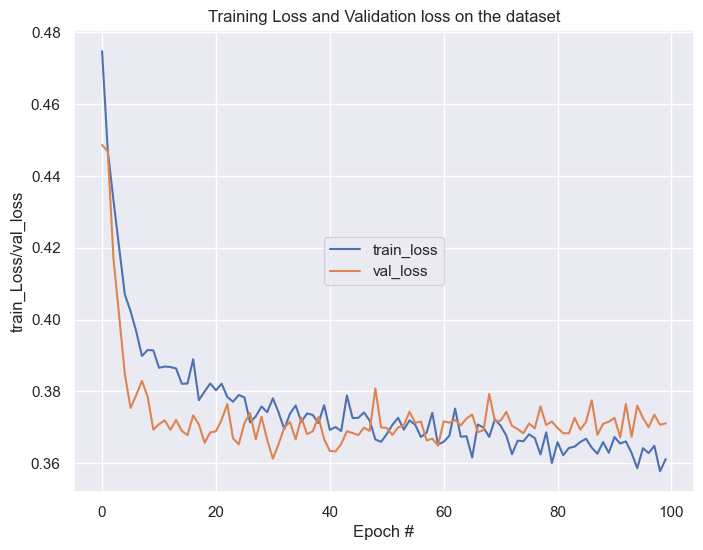

```python
N =100
plt.figure(figsize=(8,6))
plt.plot(np.arange(0, N), history_h.history["loss"], label="train_loss")
plt.plot(np.arange(0, N), history_h.history["val_loss"], label="val_loss")

plt.title("Training Loss and Validation loss on the dataset")
plt.xlabel("Epoch #")
plt.ylabel("train_Loss/val_loss")
plt.legend(loc="center")
plt.show()
```

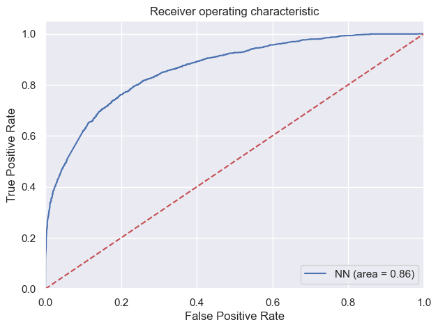

```python
# ROC-AUC on training set
NN_roc_auc_train = roc_auc_score(y_train, estimator_v2.predict(X_train))
fpr, tpr, thresholds = roc_curve(y_train, estimator_v2.predict(X_train))
plt.figure(figsize=(7, 5))
plt.plot(fpr, tpr, label="NN (area = %0.2f)" % NN_roc_auc_train)
plt.plot([0, 1], [0, 1], "r--")
plt.xlim([0.0, 1.0])
plt.ylim([0.0, 1.05])
plt.xlabel("False Positive Rate")
plt.ylabel("True Positive Rate")
plt.title("Receiver operating characteristic")
plt.legend(loc="lower right")
plt.show()
```

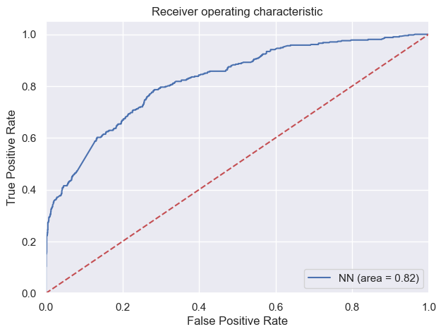

```python
# ROC-AUC on training set
NN_roc_auc_train = roc_auc_score(y_test, estimator_v2.predict(X_test))
fpr, tpr, thresholds = roc_curve(y_test, estimator_v2.predict(X_test))
plt.figure(figsize=(7, 5))
plt.plot(fpr, tpr, label="NN (area = %0.2f)" % NN_roc_auc_train)
plt.plot([0, 1], [0, 1], "r--")
plt.xlim([0.0, 1.0])
plt.ylim([0.0, 1.05])
plt.xlabel("False Positive Rate")
plt.ylabel("True Positive Rate")
plt.title("Receiver operating characteristic")
plt.legend(loc="lower right")
plt.show()
```

```python
# The optimal cut off would be where tpr is high and fpr is low
fpr, tpr, thresholds = roc_curve(y_train, estimator_v2.predict(X_train))

optimal_idx = np.argmax(tpr - fpr)
optimal_threshold_auc_roc = thresholds[optimal_idx]
print(optimal_threshold_auc_roc)
```

```
0.24808417
```

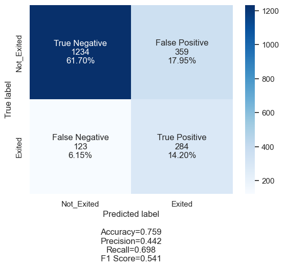

```python
## Confusion Matrix on testing set

y_pred4 = estimator_v2.predict(X_test)
for i in range(len(y_test)):
    if y_pred4[i] > optimal_threshold_auc_roc:
        y_pred4[i] = 1
    else:
        y_pred4[i] = 0


cm2 = confusion_matrix(y_test, y_pred4)
labels = ["True Negative", "False Positive", "False Negative", "True Positive"]
categories = ["Not_Exited", "Exited"]
make_confusion_matrix(cm2,
                      group_names=labels,
                      categories=categories,
                      cmap="Blues")
```

Hyperparameter tuning is used here to get a better accuracy but accuracy might differ each time. Other hyperparameters can also be tuned to get a better accuracy. Here, Recall of the model is slighty changed but the accuracy is slightly degraded.

### Model Improvement: Neural Network model with balanced data[SMOTE]

```python
!pip install -U imbalanced-learn
```

```
Downloading imbalanced_learn-0.11.0-py3-none-any.whl (235 kB)
   ---------------------------------------- 0.0/235.6 kB ? eta -:--:--
   ---------------------------------------  235.5/235.6 kB 4.8 MB/s eta 0:00:01
   ---------------------------------------- 235.6/235.6 kB 2.4 MB/s eta 0:00:00
```

```python
from imblearn.over_sampling import SMOTE
sm  = SMOTE(random_state=42)
X_train_us, y_train_us = sm.fit_resample(X_train, y_train)
print('After UpSampling, the shape of train_X: {}'.format(X_train_us.shape))
print('After UpSampling, the shape of train_y: {} \n'.format(y_train_us.shape))
```

```
After UpSampling, the shape of train_X: (10192, 11)
After UpSampling, the shape of train_y: (10192,)
```

```python
y_train_us.value_counts()
```

```
Exited
1    5096
0    5096
Name: count, dtype: int64
```

Both the classes have equal number of data thus, the dataset is balanced now

```python
backend.clear_session()
#Fixing the seed for random number generators so that we can ensure we receive the same output everytime
np.random.seed(2)
import random
random.seed(2)
tf.random.set_seed(2)
```

```python
#Initializing the model
model_4 = Sequential()
# Adding input layer of 32 neurons with relu as activation function
model_4.add(Dense(32,activation='relu',input_dim = X_train_us.shape[1]))
# Adding the dropout
model_4.add(Dropout(0.2))
# Adding hidden layer with 16 neurons with relu as activation function
model_4.add(Dense(16,activation='relu'))
# Adding the dropout
model_4.add(Dropout(0.1))
# Adding hidden layer with 8 neurons with relu as activation function
model_4.add(Dense(8,activation='relu'))
# Adding the output layer
model_4.add(Dense(1, activation = 'sigmoid'))
```

```python
model_4.summary()
```

```
Model: "sequential"
_________________________________________________________________
 Layer (type)                Output Shape              Param #
=================================================================
 dense (Dense)               (None, 32)                384

 dropout (Dropout)           (None, 32)                0

 dense_1 (Dense)             (None, 16)                528

 dropout_1 (Dropout)         (None, 16)                0

 dense_2 (Dense)             (None, 8)                 136

 dense_3 (Dense)             (None, 1)                 9

=================================================================
Total params: 1057 (4.13 KB)
Trainable params: 1057 (4.13 KB)
Non-trainable params: 0 (0.00 Byte)
_________________________________________________________________
```

```python
# Defining Early stopping
es_cb = callbacks.EarlyStopping(monitor='val_loss', min_delta=0.001, patience=5)
# Initializing Adam optimizer
optimizer = tf.keras.optimizers.Adam(0.001)
# Complining the model with binary cross entropy as loss and accuracy as metrics
model_4.compile(optimizer = optimizer,loss = 'binary_crossentropy', metrics = ['accuracy'])
# Fitting the model on train and test with batch_size of 64, epochs of 100
history_4 = model_4.fit(X_train_us,y_train_us,batch_size=64,epochs=100,verbose=1,validation_data = (X_val,y_val))
```

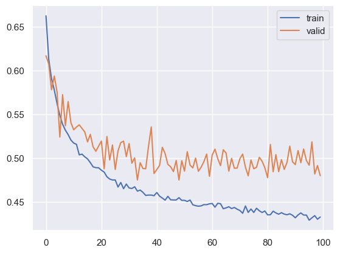

```python
# Capturing learning history per epoch
hist  = pd.DataFrame(history_4.history)
hist['epoch'] = history.epoch

# Plotting accuracy at different epochs
plt.plot(hist['loss'])
plt.plot(hist['val_loss'])
plt.legend(("train" , "valid") , loc =0)
```

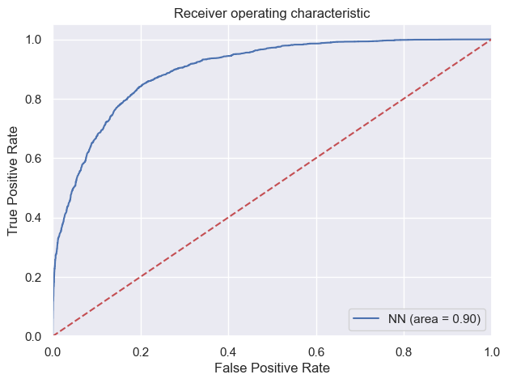

```python
# ROC-AUC on training set
NN_roc_auc_train = roc_auc_score(y_train_us, model_4.predict(X_train_us))
fpr, tpr, thresholds = roc_curve(y_train_us, model_4.predict(X_train_us))
plt.figure(figsize=(7, 5))
plt.plot(fpr, tpr, label="NN (area = %0.2f)" % NN_roc_auc_train)
plt.plot([0, 1], [0, 1], "r--")
plt.xlim([0.0, 1.0])
plt.ylim([0.0, 1.05])
plt.xlabel("False Positive Rate")
plt.ylabel("True Positive Rate")
plt.title("Receiver operating characteristic")
plt.legend(loc="lower right")
plt.show()
```

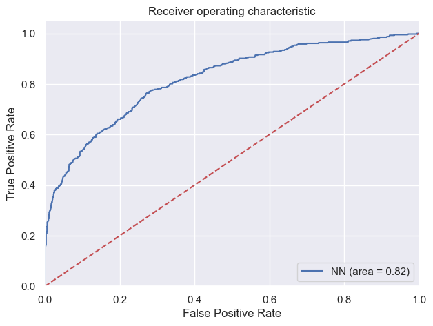

```python
# ROC-AUC on testing set
NN_roc_auc_train = roc_auc_score(y_test, model_4.predict(X_test))
fpr, tpr, thresholds = roc_curve(y_test, model_4.predict(X_test))
plt.figure(figsize=(7, 5))
plt.plot(fpr, tpr, label="NN (area = %0.2f)" % NN_roc_auc_train)
plt.plot([0, 1], [0, 1], "r--")
plt.xlim([0.0, 1.0])
plt.ylim([0.0, 1.05])
plt.xlabel("False Positive Rate")
plt.ylabel("True Positive Rate")
plt.title("Receiver operating characteristic")
plt.legend(loc="lower right")
plt.show()
```

```python
# The optimal cut off would be where tpr is high and fpr is low
fpr, tpr, thresholds = roc_curve(y_train_us, model_4.predict(X_train_us))

optimal_idx = np.argmax(tpr - fpr)
optimal_threshold_auc_roc = thresholds[optimal_idx]
print(optimal_threshold_auc_roc)
```

```
0.49653384
```

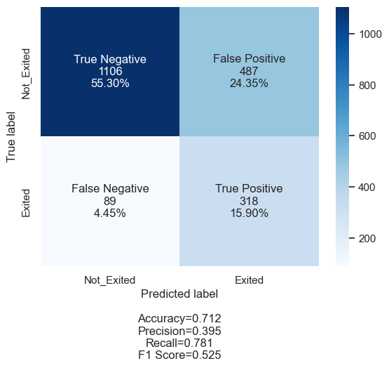

```python
## Confusion Matrix on testing set

y_pred5 = model_4.predict(X_test)
for i in range(len(y_test)):
    if y_pred5[i] > optimal_threshold_auc_roc:
        y_pred5[i] = 1
    else:
        y_pred5[i] = 0


cm2 = confusion_matrix(y_test, y_pred5)
labels = ["True Negative", "False Positive", "False Negative", "True Positive"]
categories = ["Not_Exited", "Exited"]
make_confusion_matrix(cm2,
                      group_names=labels,
                      categories=categories,
                      cmap="Blues")
```

Recall is very high but, accuracy and precision are less

Note: - ANN used on the synthesized data ( SMOTE ) was also working fine but we can not believe in this model because here we have generated the data artificially and this might also be the case that a particular data point generated in SMOTE might not make sense. Therefore, we really can not believe in a model trained on resampled data. We can try to use a cost-sensitive loss function in place of SMOTE.

Seems like this data will be overfitted when we try to apply more hyperparameter tuning and works fine for a simple model having two-three layers with a small dropout ratio. So, we can choose the Final model as model_dr which is using dropout and works on an imbalanced dataset.